# 8 Dimensionality

Psychologische Institut für psychologische Methodenlehre, Evaluation und Statistik

~

Carolina Fellinghauer

carolina.fellinghauer@uzh.ch

4 11 2020

Install `plotrix` and `rgl`, and load following libraries

```r
# library(iarm) library(corrplot)
library(eRm)
library(plotrix)
library(rgl)  #library for 3-dimensional plotting functions
```

# Unidimensionality

Unidimensionality is a fundamental assumption in the Rasch model. Unidimensionality expects that item parameter are on the same common measurement continuum. This would mean that, for example, the MDS would measure only one single latent construct, namely “physical capacity” and the SRG measures only “stress related growth”.

In presence of multidimensionality, some items of the scale measure strongly different aspect of the latent characteristic and a single interval-scaled sum score is not meaningful anymore. While local item dependency and unidimensionality assessment may be related, local item dependency focus on pairwise dependencies. Also local item dependency is not a condition for multidimensionality (Christensen, Kreiner, and Mesbah 2013).

As for the LID analysis, the dimensionality analysis is interested in detecting patterns in the standardized Rasch-residual matrix.

# Diagnostics

Several approaches are available to test the multidimensionality of an assessment scale. This lesson will cover only one possible approach, i.e. the principal component analysis (PCA).

## Principal Component Analysis (PCA)

Principal component analysis (PCA) is a technique that allows to reduce the dimensionality of datasets and to identify clusters of similar variables.

PCA needs no distributional assumptions and is therefore an adaptive exploratory method which can be used on numerical data of various types.

The PCA algorithm is very technical and requires a solid knowledge of matrix operations and linear algebra to be understood deeply. PC can be obtained through eigendecomposition (for square matrices, like the correlation matrix) or singular value decomposition (SVD). PCA is closely related to factor analysis.

The main idea of the PCA is to achieve a reduction of the dimensionality in a dataset, while preserving as much ‘variability’ (i.e. statistical information) as possible, i.e. through maximizing the variance in each dimension.

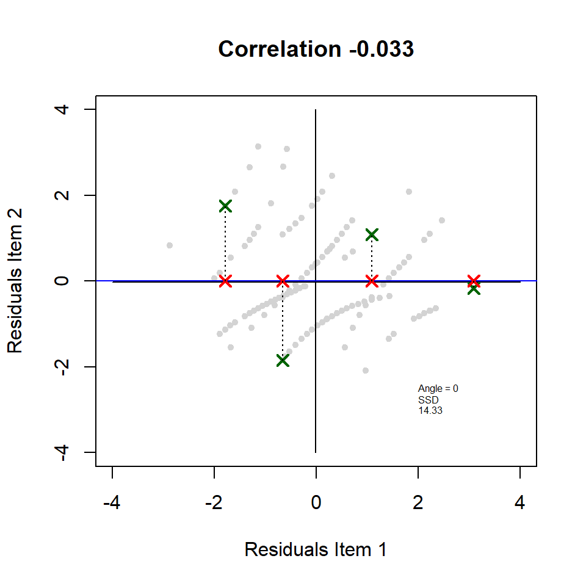

Figure 5

In Rasch analysis, in order to determine the dimensionality of a set of variables of a scale, the standardized residuals or the correlations of these are submitted to a PCA.

The lesson won’t give the computational background to this method and focus only on how to run the analysis in R and how to interpret the outputs.

### Numeric Output Analysis

Call the SRG-Data

```r
# get the SRG datasets

urlfile <- "https://raw.githubusercontent.com/CarolinaFellinghauer/UNIZH_HS2020_Rasch/master/Data/SRG_Data_Course_UNIZH.csv?token=AB5GB47UIUWV7F5NMGA33T27K5IQ2"

srg.data <- read.csv(url(urlfile))

dim(srg.data)
colnames(srg.data)

srg.items <- c("SRG1", "SRG2", "SRG3", "SRG4", "SRG5", "SRG6", "SRG7", "SRG8", "SRG9",
    "SRG10", "SRG11", "SRG12", "SRG13", "SRG14", "SRG15")

# dataset with only the SRG items
data.srg <- srg.data[, srg.items]

# check response coding (frequencies including missing values) for each SRG-item
apply(data.srg, 2, table, useNA = "always")
```

We start by running a Partial Credit Model (PCM) analysis to obtain the standardized residuals.

```r
PCM.srg <- PCM(data.srg)
PP.srg <- person.parameter(PCM.srg)
resid.srg <- residuals(PP.srg)
```

Before starting with the PCA, let’s examine residual’s pattern with a simple example using the two first items, ´SRG1´and ´SRG2´. One observation for example, circled in red, shows a very negative residual on the first item and rather positive residual on the second item.

In Rasch analysis, the standardized residual ($z_{ni}$) is given by

$$z_{ni} = \frac{x_{ni} - E[x_{ni}]}{\sqrt(V[x_{ni}])}$$
where $E[x_{ni}]$ is the expected value given person $n$’s and item $i$ parameter estimates (the $\theta_n$ and $\delta_i$) and $V[x_{ni}]$ its variance. Values close to zero indicate that a person’s item rating fits the model well. Negative residual values indicate that the model would expect a larger rating from a person on an item. Positive residual values indicate that the model would expect a smaller rating from a person.

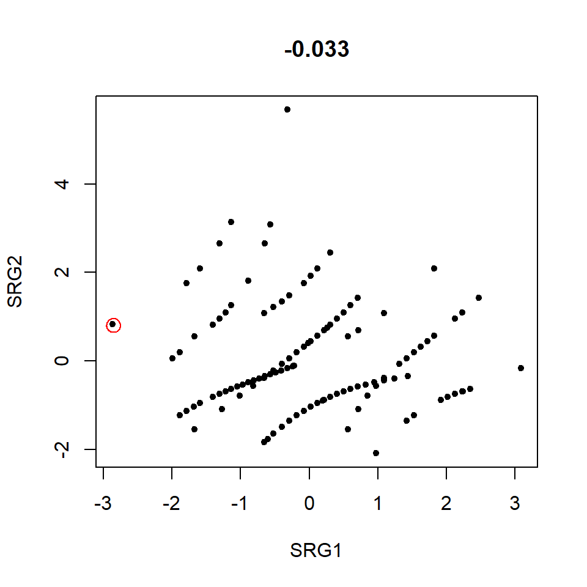

Figure 1

```r
plot(resid.srg[, 1], resid.srg[, 2], pch = 20, xlab = "SRG1", ylab = "SRG2", main = round(cor(resid.srg[,
    1], resid.srg[, 2], use = "pairwise.complete.obs"), 3))
draw.circle(-2.85, 0.8, radius = 0.1, border = "red")
```

```r
RR <- as.data.frame(resid.srg)  #Rasch residuals as data.frame instead of matrix
plot3d(RR$SRG1, RR$SRG13, RR$SRG15, xlab = "SRG1", ylab = "SRG13", zlab = "SRG15")
```

[interactive chart not shown]

Detecting patterns in a three dimensional space is already not that easy. With 4 or more dimensions, plotting and making sense of all item residuals is impossible. Dimension reduction with a PCA is one solution. A PCA allows to convert the information among all of the item residuals into fewer dimensions. Items residuals that are highly correlated cluster together and can be seen as just one dimension.

Technically, two approaches are possible, either the residual correlation matrix is submitted to a eigendecomposition using the function `eigen()` or the residuals are passed to the function `prcomp()` to perform a singular value decomposition (SVD). SVD is more generic.

Both approaches base on an algebraic approach which factorizes an input matrix into several component matrices to expose properties of the original matrix. Both approaches deliver a component loading matrix (also eigenvector) and score loadings (also eigenvalue). In what follows, we are interested in examining the matrix of the component loadings that `eigen()` delivers.

```r
cor.srg <- cor(resid.srg, use = "pairwise.complete.obs")
PCA.srg <- eigen(cor.srg)
Eigen.Vector.srg <- round(PCA.srg$vectors, 3)
colnames(Eigen.Vector.srg) <- paste("PC", 1:ncol(data.srg), sep = "")
rownames(Eigen.Vector.srg) <- colnames(data.srg)
Eigen.Vector.srg
```

```
         PC1    PC2    PC3    PC4    PC5    PC6    PC7    PC8    PC9   PC10
SRG1   0.362 -0.012  0.084  0.091 -0.276  0.528  0.400 -0.083 -0.022 -0.118
SRG2  -0.346  0.269  0.098  0.123 -0.307  0.373 -0.004 -0.233 -0.201 -0.226
SRG3  -0.055  0.353 -0.363 -0.244  0.286  0.172 -0.050  0.186  0.205 -0.184
SRG4  -0.355 -0.190 -0.037 -0.418  0.244  0.267 -0.123  0.133  0.112  0.087
SRG5  -0.405 -0.232  0.210  0.117  0.170 -0.004  0.261 -0.244  0.062  0.491
SRG6   0.084  0.353  0.094  0.398  0.387  0.068 -0.219  0.271 -0.130 -0.060
SRG7   0.112  0.373 -0.092 -0.162  0.240 -0.317  0.400 -0.417 -0.132  0.089
SRG8  -0.242 -0.072  0.265  0.435  0.002 -0.331  0.158  0.158  0.409 -0.395
SRG9   0.256 -0.146  0.297 -0.249  0.072 -0.165  0.353  0.522 -0.343 -0.006
SRG10  0.148 -0.080  0.444 -0.045  0.135 -0.039 -0.550 -0.285 -0.357 -0.048
SRG11  0.377 -0.158  0.182 -0.282 -0.065 -0.032 -0.170 -0.221  0.573 -0.143
SRG12  0.158  0.397 -0.032  0.089 -0.392 -0.205 -0.194  0.120  0.191  0.550
SRG13  0.112 -0.264 -0.496  0.148  0.064 -0.281 -0.021 -0.287 -0.196 -0.260
SRG14 -0.299 -0.005 -0.093 -0.282 -0.514 -0.305 -0.106  0.163 -0.216 -0.174
SRG15  0.147 -0.404 -0.380  0.319 -0.046  0.151 -0.129  0.168 -0.064  0.249
        PC11   PC12   PC13   PC14   PC15
SRG1  -0.076 -0.418  0.035 -0.267 -0.252
SRG2   0.071  0.502  0.124  0.269 -0.244
SRG3   0.539 -0.239 -0.084  0.159 -0.277
SRG4  -0.499 -0.053  0.373 -0.081 -0.284
SRG5   0.376  0.012 -0.186 -0.259 -0.282
SRG6  -0.221  0.206 -0.241 -0.451 -0.228
SRG7  -0.378 -0.048 -0.161  0.261 -0.237
SRG8  -0.094 -0.236  0.155  0.219 -0.238
SRG9   0.194  0.278  0.167  0.120 -0.242
SRG10  0.131 -0.364  0.062  0.184 -0.228
SRG11  0.004  0.396 -0.229 -0.086 -0.267
SRG12  0.029 -0.036  0.395 -0.031 -0.252
SRG13  0.145  0.129  0.414 -0.327 -0.249
SRG14 -0.087 -0.164 -0.433 -0.252 -0.254
SRG15 -0.150  0.031 -0.308  0.460 -0.322
```

The matrix of eigenvectors or the component loadings shows in which direction and how strongly the item residuals are loading. The first PC is the most important dimension, the second PC is the second most important etc… The values of the loadings in itself are less important then their pattern. To understand how items cluster, it is possible, for example, to observe the sign of the loading on the first component. Higher loadings, away from zero, indicate which items load more strongly on a component.

To determine if the opposite loading are within an acceptable range an analysis of eigenvalues is necessary. Interpretation of the eigenvalues is not straightforward. The first eigenvalue is often used as a criterion to determine if data is uni- or multidimensional.

```r
Eigen.Value.srg <- PCA.srg$values

Perc.Eigen.srg <- Eigen.Value.srg/sum(Eigen.Value.srg) * 100
Cum.Perc.Eigen.srg <- cumsum(Perc.Eigen.srg)

PCA.Table.srg <- cbind(Eigen.Value.srg, Perc.Eigen.srg, Cum.Perc.Eigen.srg)

PCA.Table.srg
```

```
      Eigen.Value.srg Perc.Eigen.srg Cum.Perc.Eigen.srg
 [1,]      1.83099421     12.2066281           12.20663
 [2,]      1.73230689     11.5487126           23.75534
 [3,]      1.50419437     10.0279625           33.78330
 [4,]      1.30228213      8.6818809           42.46518
 [5,]      1.26171263      8.4114175           50.87660
 [6,]      1.06130819      7.0753879           57.95199
 [7,]      1.01239306      6.7492871           64.70128
 [8,]      0.93249940      6.2166627           70.91794
 [9,]      0.91122070      6.0748047           76.99274
[10,]      0.79821304      5.3214203           82.31416
[11,]      0.71759422      4.7839615           87.09813
[12,]      0.67182066      4.4788044           91.57693
[13,]      0.65289308      4.3526205           95.92955
[14,]      0.58717403      3.9144936           99.84404
[15,]      0.02339337      0.1559558          100.00000
```

The first column of the table gives the eigenvalue, the next column express this value as a percentage and the last the cumulative percentage. The last column would be interpreted as for example 10 components are necessary to explain 80 % of the variance. Again, various cut-offs are found in the litterature. Typically, unidimensionality is assumed if the first eigenvalue is below 2, other suggests to rather look for a second eigenvalues below 1.4 (Smith and Miao 1994).

### Visual Analysis

Given the component loading matrix, it is possible to draw the position of the items in a cartesian field using the loadings on the two first components as x and y coordinates. The next figures shows the first and second PCA loading drawn in a coordinate system, to investigate how the items are grouping in a 2-dimensional space. Note that oppositions in the loadings on the x-axis (PC1) are always more relevant than those one the y-axis (PC2).

Higher positive versus higher negative loading on the first principal component (PC1) indicate items that have the highest opposite loading and may indicate a split of the latent trait measured into two strong secondary aspects.

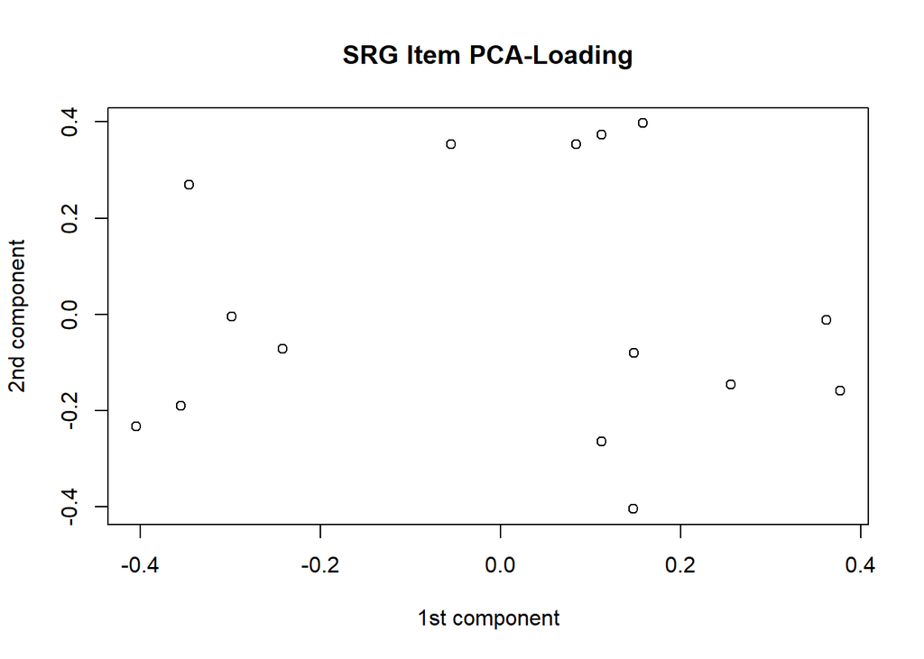

Figure 3

```r
## analysis of the PCA loading

plot(Eigen.Vector.srg[, "PC1"], Eigen.Vector.srg[, "PC2"], xlab = "1st component",
    ylab = "2nd component", main = "SRG Item PCA-Loading")
```

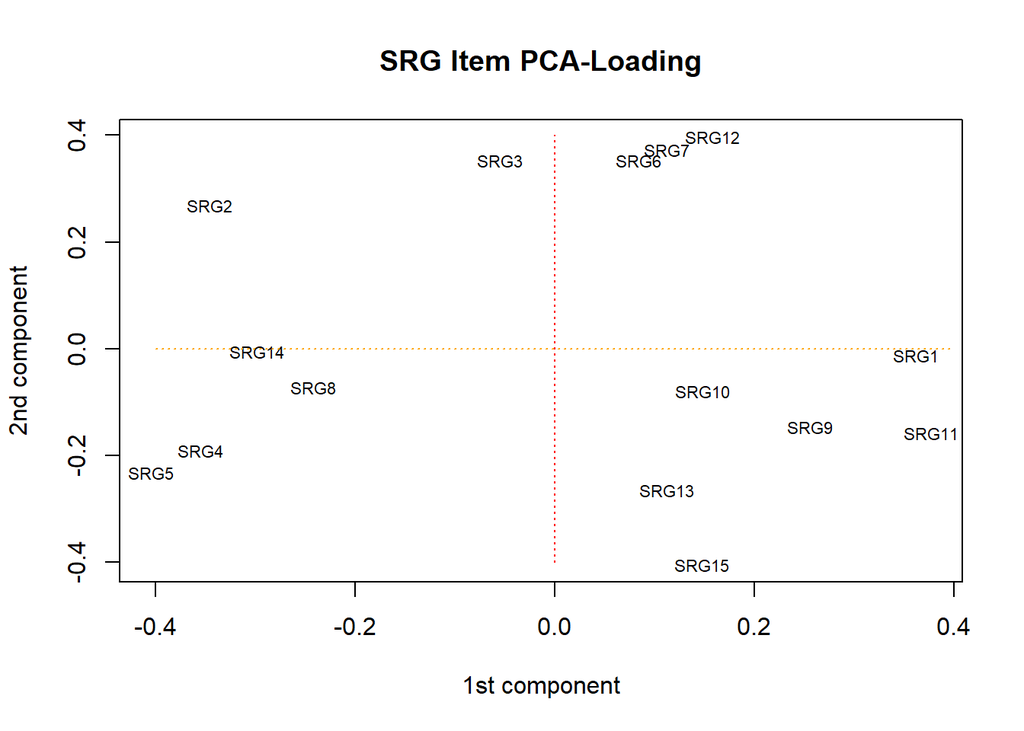

Figure 4

```r
### add labels to identify the item loading locations

plot(Eigen.Vector.srg[, "PC1"], Eigen.Vector.srg[, "PC2"], xlab = "1st component",
    ylab = "2nd component", main = "SRG Item PCA-Loading", col = "white")

text(Eigen.Vector.srg[, "PC1"], Eigen.Vector.srg[, "PC2"], colnames(data.srg), cex = 0.7)

segments(0, -0.4, 0, 0.4, col = "red", lty = "dotted")

segments(-0.4, 0, 0.4, 0, col = "orange", lty = "dotted")
```

Based on the first component, it looks like two opposite poles emerge with on one side

- SRG1 *I learned to be nicer to others*, SRG9 *I learned to listen more carefully when others talk to me*, SRG10 *I learned to be open to new information and ideas*, SRG11 *I learned to communicate more honestly with others*, SRG13 *I learned that it’s okay to ask others for help*, SRG15 *I learned that there are more people who care about me than I thought*

and on the other side

- SRG2 *I feel freer to make my own decisions*, SRG8 *I learned to be a more confident person*, SRG14 *I learned to stand up for my personal rights*, SRG4 *I learned to be myself and not try to be what others want me to be* and SRG5 *I learned to work through models and not just give up*.

**Openness to others and novelty** versus **Self-Confidence and persistence**?

Analysis of the PCA loading for the 3 first components, using the loading as x-axis, y-axis, and z-axis coordinates allows to show the item grouping in a 3-dimensional space.

```r
plot3d(Eigen.Vector.srg[, "PC1"], Eigen.Vector.srg[, "PC2"], Eigen.Vector.srg[, "PC3"],
    xlab = "PC1", ylab = "PC2", zlab = "PC3", type = "s", radius = 0, col = "white")

text3d(Eigen.Vector.srg[, "PC1"], Eigen.Vector.srg[, "PC2"], Eigen.Vector.srg[, "PC3"],
    texts = rownames(Eigen.Vector.srg))
```

[interactive chart not shown]

On PC2, a group of items seem to detach from the rest SRG12 *I learned that I want to have some impact on the world*, SRG7 *I learned to how to reach out and help others* and SRG6 *I learned to find more meaning in life*, **Meaning of life**?

SRG3 *I learned that I have something of value to teach others about life* which appeared close to this group in the 2 dimensional representation, is now even more detached when adding the third dimension.

The analysis of the PC loading, shows us relatively meaningful residual cluster in terms of the content they measure. However, this is not sufficient to conclude that the scale is not unidimensional.

Screeplot or barplot of the eigenvalues show the change in eigenvalues. It could be shown in terms of variation to the origin, i.e. the percentag of variation they account for. The elbow, were the line “flexes” in is usually indicative of the number of dimensions. Here the line does not seem to peek downwards, starting from an acceptable level, first eigenvalue being 1.8.

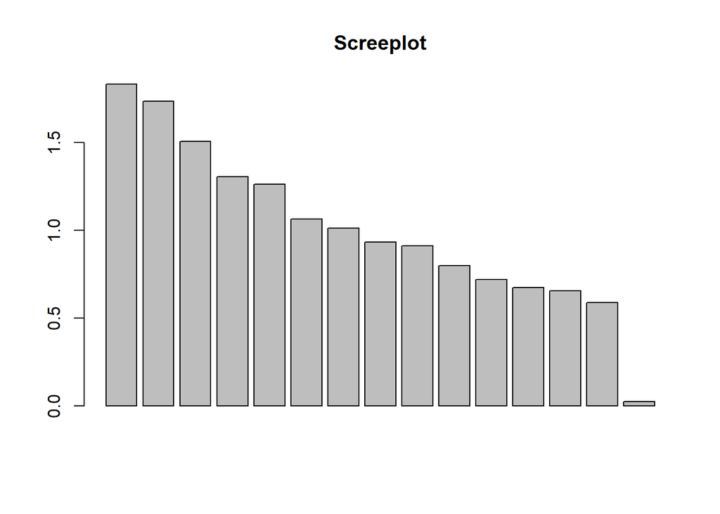

Figure 6

```r
barplot(Eigen.Value.srg, main = "Screeplot")
```

The figures and the eigenvalue table, especially the column for the cumulative proportion of variation that each additional PC brings, shows that this instrument is not loading strongly on the first components. It may indicate the absence of a dominant PC but also the absence of multiple dimensions.

Technically, it is also possible to start by looking at the eigenvalues and if they confirm unidimensionality it is not absolutely necessary to plot the locations of the items. However, plotting the PC loadings gives interesting information about the latent construct under investigation.

# Exercise

Using the MDS Data :

1. compute eigenvalues and
2. draw a scree plot which shows the proportion of variation that each PC accounts for.
3. Is it unidimensional?

Based on the proportion of variance that the 3 first PC explain:

4. Draw a 2-dimensional or a 3-dimensional PC loading plot. What do you observe?

# References

Christensen, Karl Bang, Svend Kreiner, and Mounir Mesbah. 2013. *Rasch Models in Health*. London: ISTE ; Hoboken, NJ : John Wiley & Sons.

Smith, R. M., and C. Y. Miao. 1994. “Assessing Unidimensionality for Rasch Measurement.” In *Objective Measurement: Theory into Practice. Volume 2*. Greenwich: Ablex: M. Wilson.